# **COMPARISON OF DISTINCT CNN BACKBONE ARCHITECTURES WITH DENSE HEADS, ATTENTION AND VISUAL TRANSFORMERS ON MEDICAL X-RAY IMAGE DATASET**

## AASD 4015 - Advance Mathematical Concepts for Deep Learning Group Project 2

**Members:**

1. Saksham Prakash (101410709)
2. Sik Yin Sun (101409665)

Project GitHub: https://github.com/SikYinSun/AASD-4015---COVID-19-Detection

## Background and Motivation

The COVID-19 pandemic has had a profound impact on global health and early diagnosis of COVID-19 is critical for effective management of the disease.

For this project, we explore **different backbone architecures** and their results on a binary-classification task using images of X-Rays of patients with/without the disease. Additionally, since the **attention mechanism** has been quite successful recently, our attempts on utilizing the same for our purpose, has been detailed as well.

In the context of COVID screening from X-rays, a **high recall would be preferred over high precision** . This is because the consequences of a false negative - i.e., failing to identify a COVID-19 infection in a patient who actually has the disease - can be severe. Patients with COVID-19 can develop severe symptoms and require urgent medical attention, and failure to detect the disease can result in delayed treatment and increased transmission.

On the other hand, the consequences of a false positive - i.e., identifying a patient as having COVID-19 when they do not - are less severe. In the case of false positives, the patient may be required to undergo additional testing or quarantine measures, but this is a relatively minor inconvenience compared to the potential harm of a false negative.

Therefore, in the case of COVID screening from X-rays, a high recall model that detects as many true positive cases as possible, even if it results in some false positives, is preferred over a high precision model that minimizes false positives at the expense of potentially missing true positive cases.

## Problem Statement

1. The objective is to develop a binary classification model capable of distinguishing between COVID-19 infected and non-infected individuals using a chest X-ray image of a patient.
2. Compare the efficacy of different backbone architectures with dense heads, attention heads and visual transformers for this purpose.

## Contents

| SNo. | Contents | Link |
| --- | --- | --- |
| 1 | **Libraries Setup** | Jump To Cell |
| 2 | **Data - Chest X-Rays** | Jump To Cell |
| 2.1 | Download | Jump To Cell |
| 2.2 | Initial Exploration | Jump To Cell |
| 2.3 | Handling Class Imbalance by Oversampling | Jump To Cell |
| 3 | **Helper Functions to Evaluate Model Trainings Uniformally** | Jump To Cell |
| 4 | **Training Simple Dense Heads for Implementing Baseline Backbone Architectures** | Jump To Cell |
| 4.1 | VGG-16 | Jump To Cell |
| 4.2 | InceptionV3 | Jump To Cell |
| 4.3 | EffientNetV2B3 | Jump To Cell |
| 5 | **Using Attention Mechanism** | Jump To Cell |
| 5.1 | VGG-16 backbone with Self-Attention | Jump To Cell |
| 5.2 | VGG-16 backbone with Multi-Head Attention | Jump To Cell |
| 6 | **Visual Transformers (ViT)** | Jump To Cell |
| 7 | **Results** | Jump To Cell |
| 8 | **Conclusion** | Jump To Cell |
| 9 | **Learning Outcomes** | Jump To Cell |
| 10 | **References** | Jump To Cell |

## **1. Libraries Setup**

### 1.1 Downloading Packages

```python
!pip install tensorflow-addons vit-keras typing_extensions typeguard seaborn scikit-learn seaborn opencv-python kaggle imbalanced-learn
```

### 1.2 Imports

```python
import os
import numpy as np
from glob import glob
import seaborn as sns
import matplotlib.pyplot as plt
from sklearn.metrics import classification_report, confusion_matrix
from sklearn.model_selection import train_test_split
import gc

import tensorflow as tf
from tensorflow.keras import layers
from tensorflow.keras.applications import VGG16, inception_v3, efficientnet_v2
from tensorflow.keras.layers import Flatten, Dense
from tensorflow.keras.models import Model
from tensorflow.keras.optimizers import Adam
from vit_keras import vit

from imblearn.over_sampling import RandomOverSampler
from imblearn.keras import balanced_batch_generator
from sklearn.utils import shuffle
from tensorflow.keras.preprocessing.image import load_img, img_to_array
```

```python
print("Num GPUs Available: ", len(tf.config.list_physical_devices('GPU')))
```

```
Num GPUs Available:  1
```

[output not shown]

## **2. Data - Chest X-Rays**

The link of Data: https://www.kaggle.com/datasets/paultimothymooney/chest-xray-pneumonia

### 2.1 Download

```python
os.environ['KAGGLE_CONFIG_DIR'] = "."
if not os.path.exists('chest_xray'):
    !kaggle datasets download -d paultimothymooney/chest-xray-pneumonia --unzip
```

```python
train_dir = os.path.join('.','chest_xray','train')
val_dir = os.path.join('.','chest_xray','val')
test_dir = os.path.join('.','chest_xray','test')
```

```python
img_height = 320
img_width = 320
batch_size = 16
seed = 9876
```

### 2.2 Initial Exploration

```python
train_data = tf.keras.preprocessing.image_dataset_from_directory(train_dir, image_size=(img_height, img_width), batch_size = batch_size, shuffle = True, seed=seed)
val_data = tf.keras.preprocessing.image_dataset_from_directory(val_dir, image_size=(img_height, img_width), batch_size = batch_size, shuffle = True, seed=seed)
test_data = tf.keras.preprocessing.image_dataset_from_directory(test_dir, image_size=(img_height, img_width), batch_size = batch_size, shuffle = True, seed=seed)
```

```
Found 5216 files belonging to 2 classes.
Found 16 files belonging to 2 classes.
Found 624 files belonging to 2 classes.
```

```python
class_label = train_data.class_names
train_num = []
val_num = []
test_num = []
print("Train Data")
for i in class_label:
    num_files = len(os.listdir(os.path.join(train_dir, i)))
    train_num.append(num_files)
    print(f"{i}: {num_files} files")

print("\nValidation Data")
for i in class_label:
    num_files = len(os.listdir(os.path.join(val_dir, i)))
    val_num.append(num_files)
    print(f"{i}: {num_files} files")

print("\nTest Data")
for i in class_label:
    num_files = len(os.listdir(os.path.join(test_dir, i)))
    test_num.append(num_files)
    print(f"{i}: {num_files} files")
```

```
Train Data
NORMAL: 1341 files
PNEUMONIA: 3875 files

Validation Data
NORMAL: 8 files
PNEUMONIA: 8 files

Test Data
NORMAL: 234 files
PNEUMONIA: 390 files
```

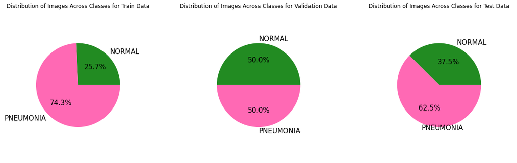

```python
colors = ['#228b22', '#ff69b4']
fig, axs = plt.subplots(ncols=3, figsize=(20, 6))
fig.set_facecolor('white')
axs[0].pie(train_num, labels=class_label, autopct='%1.1f%%', colors = colors, textprops={'fontsize': 15}, radius=0.7, center=(0.5, 0.5))
axs[0].set_title('Distribution of Images Across Classes for Train Data')
axs[1].pie(val_num, labels=class_label, autopct='%1.1f%%', colors = colors, textprops={'fontsize': 15}, radius=0.7, center=(0.5, 0.5))
axs[1].set_title('Distribution of Images Across Classes for Validation Data')
axs[2].pie(test_num, labels=class_label, autopct='%1.1f%%', colors = colors, textprops={'fontsize': 15}, radius=0.7, center=(0.5, 0.5))
axs[2].set_title('Distribution of Images Across Classes for Test Data')
plt.show()
```

[output not shown]

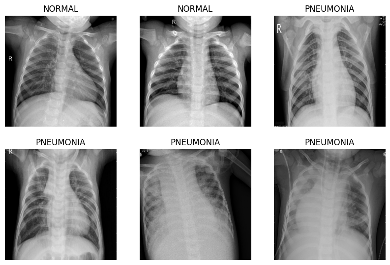

```python
plt.figure(figsize = (10,10))
for images, labels in train_data.take(1):
  for i in range(6):
    ax = plt.subplot(3, 3, i+1)
    plt.imshow(images[i].numpy().astype('uint8'))
    plt.title(class_label[labels[i]])
    plt.axis('off')
```

```python
del train_data
del val_data
del test_data
gc.collect()
```

```
463
```

After briefly exploring the data, we found out that there is a vast difference between "normal" and "pneumonia" for the train data. Additionally, we found that there is more pneumonia record than normal. From the image above, we can see them for people with pneumonia. Their X-ray pictures are much blurry than normal people, and we believe that is because the lung infection causes some fluid there.

### 2.3 Handling Class Imbalance by Oversampling

```python
def load_images_from_directory(dir_path, class_names, target_size=(320, 320)):
    images = []
    labels = []
    for class_name in class_names:
        class_dir = os.path.join(dir_path, class_name)
        for file in os.listdir(class_dir):
            img_path = os.path.join(class_dir, file)
            img = load_img(img_path, target_size=target_size)
            img_array = img_to_array(img)
            images.append(img_array)
            labels.append(class_names.index(class_name))
    return np.array(images), np.array(labels)

def get_balanced_train_data(train_dir, class_names, img_height, img_width):
    X, y = load_images_from_directory(train_dir, class_names, target_size=(img_height, img_width))
    ros = RandomOverSampler(sampling_strategy='minority')
    X_resampled, y_resampled = ros.fit_resample(X.reshape(X.shape[0], -1), y)
    X_resampled = X_resampled.reshape(X_resampled.shape[0], img_height, img_width, 3)
    X_resampled, y_resampled = shuffle(X_resampled, y_resampled, random_state=42)
    return X_resampled, y_resampled

def create_dataset(X, y, batch_size=16):
    X = X.astype('float32') / 255.0
    dataset = tf.data.Dataset.from_tensor_slices((X, y))
    dataset = dataset.shuffle(buffer_size=len(X)).batch(batch_size).prefetch(buffer_size=tf.data.experimental.AUTOTUNE)
    return dataset
```

```python
X, y = get_balanced_train_data(train_dir, class_label, img_height, img_width)
X_train, X_val, y_train, y_val = train_test_split(X, y, test_size=0.2, random_state=seed)
train_data = create_dataset(X_train, y_train, batch_size=16)
val_data = create_dataset(X_val, y_val, batch_size=16)
```

```
2023-04-06 11:50:24.641693: W tensorflow/tsl/framework/cpu_allocator_impl.cc:83] Allocation of 7618560000 exceeds 10% of free system memory.
2023-04-06 11:50:31.888464: W tensorflow/tsl/framework/cpu_allocator_impl.cc:83] Allocation of 7618560000 exceeds 10% of free system memory.
```

```python
X_test, y_test = get_balanced_train_data(test_dir, class_label, img_height, img_width)
test_data = create_dataset(X_test, y_test, batch_size=16)
```

```python
print(np.unique(y_train, return_counts=True))
print(np.unique(y_val, return_counts=True))
print(np.unique(y_test, return_counts=True))
```

```
(array([0, 1]), array([3110, 3090]))
(array([0, 1]), array([765, 785]))
(array([0, 1]), array([390, 390]))
```

## **3. Helper Functions to Evaluate Model Trainings Uniformally**

```python
def plot_accuracy_and_loss(history):
    fig, ax = plt.subplots(ncols=2, figsize=(25, 8))

    ax[0].plot(history.history['accuracy'], label="Train accuracy")
    ax[0].plot(history.history['val_accuracy'], label="Validation accuracy")
    ax[0].set_title("Model accuracy")
    ax[0].set_xlabel("Epochs")
    ax[0].set_ylabel("accuracy")
    ax[0].legend(["train", "val"])
    ax[0].grid(True)
    ax[0].legend()

    ax[1].plot(history.history['loss'], label="Train loss")
    ax[1].plot(history.history['val_loss'], label="Validation loss")
    ax[1].set_title("Model loss")
    ax[1].set_xlabel("Epochs")
    ax[1].set_ylabel("loss")
    ax[1].legend(["train", "val"])
    ax[1].grid(True)
    ax[1].legend()

    plt.show()

def print_confusion_matrix(y_true, y_pred):
    print("\nConfusion Matrix:")
    cm = confusion_matrix(y_true, y_pred)
    sns.heatmap(cm, annot=True, fmt='d', cmap='Blues', linewidths=0.5, cbar=False)
    plt.xlabel("Predicted")
    plt.ylabel("Actual")
    plt.show()

def print_classification_report(y_true, y_pred, class_names):
    print("\nClassification Report:")
    print(classification_report(y_true, y_pred, target_names=class_names, zero_division=1))

def evaluate_model(model, train_dataset, val_dataset, test_dataset, epochs=10, class_names=class_label):
    history = model.fit(train_dataset, epochs=epochs, validation_data=val_dataset)

    print("\nModel Summary:")
    print(model.summary())

    plot_accuracy_and_loss(history)

    test_loss, test_accuracy = model.evaluate(test_dataset)
    print(f"\nTest accuracy: {test_accuracy}, Test loss: {test_loss}")

    y_true = np.concatenate([y for _, y in test_dataset], axis=0)
    y_pred = np.squeeze(np.round(model.predict(test_dataset)))

    print_confusion_matrix(y_true, y_pred)
    print_classification_report(y_true, y_pred, class_names)
```

## **4. Training Simple Dense Heads for Implementing Baseline Backbone Architectures**

### 4.1 VGG-16

```python
image_size = (img_height, img_width,3)
vgg16 = VGG16(include_top = False, weights = 'imagenet',input_shape = image_size)

for layer in vgg16.layers:
    layer.trainable = False

x = Flatten()(vgg16.output)
x = Dense(256, activation='relu')(x)
x = Dense(1, activation="sigmoid")(x)

vgg16 = Model(inputs=vgg16.input, outputs=x)
vgg16.compile(loss="binary_crossentropy", optimizer='adam', metrics=["accuracy"])
```

[output not shown]

[output not shown]

[output not shown]

```
Model Summary:
Model: "model"
_________________________________________________________________
 Layer (type)                Output Shape              Param #
=================================================================
 input_1 (InputLayer)        [(None, 320, 320, 3)]     0

 block1_conv1 (Conv2D)       (None, 320, 320, 64)      1792

 block1_conv2 (Conv2D)       (None, 320, 320, 64)      36928

 block1_pool (MaxPooling2D)  (None, 160, 160, 64)      0

 block2_conv1 (Conv2D)       (None, 160, 160, 128)     73856

 block2_conv2 (Conv2D)       (None, 160, 160, 128)     147584

 block2_pool (MaxPooling2D)  (None, 80, 80, 128)       0

 block3_conv1 (Conv2D)       (None, 80, 80, 256)       295168

 block3_conv2 (Conv2D)       (None, 80, 80, 256)       590080

 block3_conv3 (Conv2D)       (None, 80, 80, 256)       590080

 block3_pool (MaxPooling2D)  (None, 40, 40, 256)       0

 block4_conv1 (Conv2D)       (None, 40, 40, 512)       1180160

 block4_conv2 (Conv2D)       (None, 40, 40, 512)       2359808

 block4_conv3 (Conv2D)       (None, 40, 40, 512)       2359808

 block4_pool (MaxPooling2D)  (None, 20, 20, 512)       0

 block5_conv1 (Conv2D)       (None, 20, 20, 512)       2359808

 block5_conv2 (Conv2D)       (None, 20, 20, 512)       2359808

 block5_conv3 (Conv2D)       (None, 20, 20, 512)       2359808

 block5_pool (MaxPooling2D)  (None, 10, 10, 512)       0

 flatten (Flatten)           (None, 51200)             0

 dense (Dense)               (None, 256)               13107456

 dense_1 (Dense)             (None, 1)                 257

=================================================================
Total params: 27,822,401
Trainable params: 13,107,713
Non-trainable params: 14,714,688
_________________________________________________________________
None
```

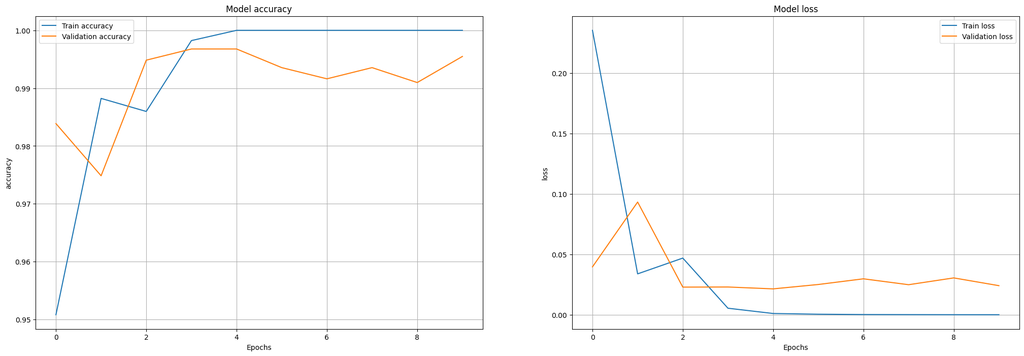

[output not shown]

```
Test accuracy: 0.6871795058250427, Test loss: 2.8468077182769775

Confusion Matrix:
```

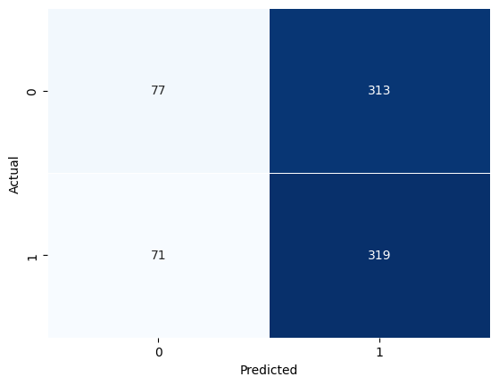

```
Classification Report:
              precision    recall  f1-score   support

      NORMAL       0.52      0.20      0.29       390
   PNEUMONIA       0.50      0.82      0.62       390

    accuracy                           0.51       780
   macro avg       0.51      0.51      0.46       780
weighted avg       0.51      0.51      0.46       780
```

```python
evaluate_model(model=vgg16, train_dataset=train_data, val_dataset=val_data, test_dataset=test_data, epochs=10)
```

For VGG16, we got a test accuracy of 0.687 and a test loss of 2.847. The precision and recall values differ for each class, with the model performing better for the "PNEUMONIA" class than for the "NORMAL" class. The confusion matrix shows that the model has more false positives for the "NORMAL" class than false negatives for the "PNEUMONIA" class, indicating that the model may be biased towards classifying samples as "PNEUMONIA."

### 4.2 InceptionV3

```python
iv3 = inception_v3.InceptionV3(include_top = False, weights = 'imagenet',input_shape = image_size)

for layer in iv3.layers:
    layer.trainable = False

x = Flatten()(iv3.output)
x = Dense(256, activation='relu')(x)
x = Dense(1, activation="sigmoid")(x)

iv3 = Model(inputs=iv3.input, outputs=x)
iv3.compile(loss="binary_crossentropy", optimizer='adam', metrics=["accuracy"])
```

```
Model Summary:
Model: "model_1"
__________________________________________________________________________________________________
 Layer (type)                   Output Shape         Param #     Connected to
==================================================================================================
 input_2 (InputLayer)           [(None, 320, 320, 3  0           []
                                )]

 conv2d (Conv2D)                (None, 159, 159, 32  864         ['input_2[0][0]']
                                )

 batch_normalization (BatchNorm  (None, 159, 159, 32  96         ['conv2d[0][0]']
 alization)                     )

 activation (Activation)        (None, 159, 159, 32  0           ['batch_normalization[0][0]']
                                )

 conv2d_1 (Conv2D)              (None, 157, 157, 32  9216        ['activation[0][0]']
                                )

 batch_normalization_1 (BatchNo  (None, 157, 157, 32  96         ['conv2d_1[0][0]']
 rmalization)                   )

 activation_1 (Activation)      (None, 157, 157, 32  0           ['batch_normalization_1[0][0]']
                                )

 conv2d_2 (Conv2D)              (None, 157, 157, 64  18432       ['activation_1[0][0]']
                                )

 batch_normalization_2 (BatchNo  (None, 157, 157, 64  192        ['conv2d_2[0][0]']
 rmalization)                   )

 activation_2 (Activation)      (None, 157, 157, 64  0           ['batch_normalization_2[0][0]']
                                )

 max_pooling2d (MaxPooling2D)   (None, 78, 78, 64)   0           ['activation_2[0][0]']

 conv2d_3 (Conv2D)              (None, 78, 78, 80)   5120        ['max_pooling2d[0][0]']

 batch_normalization_3 (BatchNo  (None, 78, 78, 80)  240         ['conv2d_3[0][0]']
```

[output cut: 729 more lines]

```
                                                                  'concatenate_1[0][0]',
                                                                  'activation_93[0][0]']

 flatten_1 (Flatten)            (None, 131072)       0           ['mixed10[0][0]']

 dense_2 (Dense)                (None, 256)          33554688    ['flatten_1[0][0]']

 dense_3 (Dense)                (None, 1)            257         ['dense_2[0][0]']

==================================================================================================
Total params: 55,357,729
Trainable params: 33,554,945
Non-trainable params: 21,802,784
__________________________________________________________________________________________________
None
```

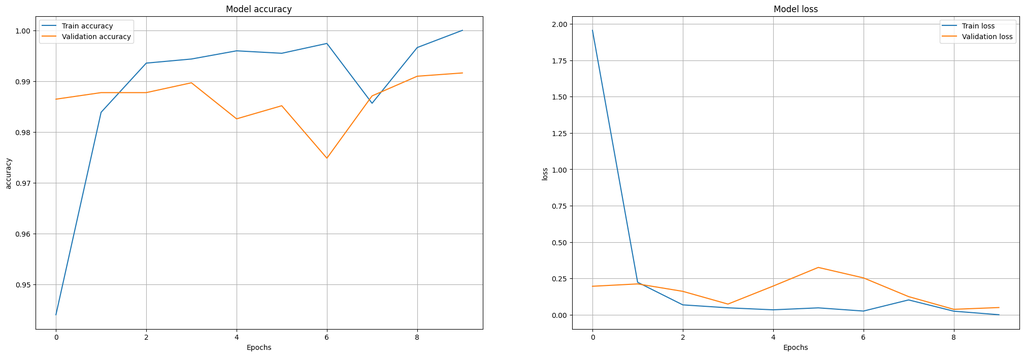

```
Test accuracy: 0.721794843673706, Test loss: 4.035737991333008

Confusion Matrix:
```

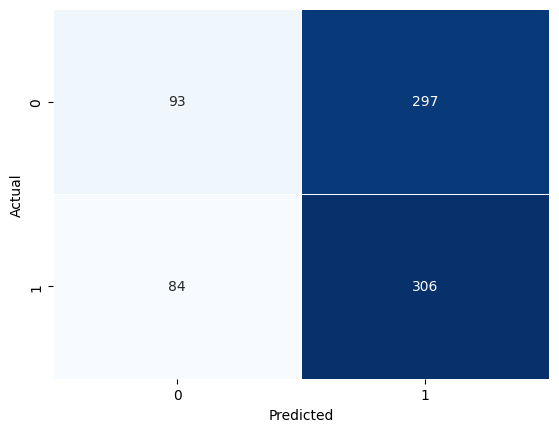

```
Classification Report:
              precision    recall  f1-score   support

      NORMAL       0.53      0.24      0.33       390
   PNEUMONIA       0.51      0.78      0.62       390

    accuracy                           0.51       780
   macro avg       0.52      0.51      0.47       780
weighted avg       0.52      0.51      0.47       780
```

```python
# history_iv3 = iv3.fit(train_data, epochs=20,validation_data = val_data)
evaluate_model(model=iv3, train_dataset=train_data, val_dataset=val_data, test_dataset=test_data, epochs=10)
```

For InceptionV3, we got a test accuracy of 0.7218 and a test loss of 4.0357. In addition, the confusion matrix shows that the model has more false positives for the "NORMAL" class than false negatives for the "PNEUMONIA" class, indicating that the model may be biased towards classifying samples as "PNEUMONIA."

### 4.3 EffientNetV2B3

```python
eff_v2 = efficientnet_v2.EfficientNetV2B3(include_top = False, weights = 'imagenet',input_shape = image_size)

for layer in eff_v2.layers:
    layer.trainable = False

x = Flatten()(eff_v2.output)
x = Dense(256, activation='relu')(x)
x = Dense(1, activation="sigmoid")(x)

eff_v2 = Model(inputs=eff_v2.input, outputs=x)
eff_v2.compile(loss="binary_crossentropy", optimizer='adam', metrics=["accuracy"])
```

```
2023-04-06 11:57:39.345723: E tensorflow/core/grappler/optimizers/meta_optimizer.cc:954] layout failed: INVALID_ARGUMENT: Size of values 0 does not match size of permutation 4 @ fanin shape inmodel_2/block1b_drop/dropout/SelectV2-2-TransposeNHWCToNCHW-LayoutOptimizer
```

```
Model Summary:
Model: "model_2"
__________________________________________________________________________________________________
 Layer (type)                   Output Shape         Param #     Connected to
==================================================================================================
 input_3 (InputLayer)           [(None, 320, 320, 3  0           []
                                )]

 rescaling (Rescaling)          (None, 320, 320, 3)  0           ['input_3[0][0]']

 normalization (Normalization)  (None, 320, 320, 3)  0           ['rescaling[0][0]']

 stem_conv (Conv2D)             (None, 160, 160, 40  1080        ['normalization[0][0]']
                                )

 stem_bn (BatchNormalization)   (None, 160, 160, 40  160         ['stem_conv[0][0]']
                                )

 stem_activation (Activation)   (None, 160, 160, 40  0           ['stem_bn[0][0]']
                                )

 block1a_project_conv (Conv2D)  (None, 160, 160, 16  5760        ['stem_activation[0][0]']
                                )

 block1a_project_bn (BatchNorma  (None, 160, 160, 16  64         ['block1a_project_conv[0][0]']
 lization)                      )

 block1a_project_activation (Ac  (None, 160, 160, 16  0          ['block1a_project_bn[0][0]']
 tivation)                      )

 block1b_project_conv (Conv2D)  (None, 160, 160, 16  2304        ['block1a_project_activation[0][0
                                )                                ]']

 block1b_project_bn (BatchNorma  (None, 160, 160, 16  64         ['block1b_project_conv[0][0]']
 lization)                      )

 block1b_project_activation (Ac  (None, 160, 160, 16  0          ['block1b_project_bn[0][0]']
 tivation)                      )

 block1b_drop (Dropout)         (None, 160, 160, 16  0           ['block1b_project_activation[0][0
```

[output cut: 1048 more lines]

```
 top_activation (Activation)    (None, 10, 10, 1536  0           ['top_bn[0][0]']
                                )

 flatten_2 (Flatten)            (None, 153600)       0           ['top_activation[0][0]']

 dense_4 (Dense)                (None, 256)          39321856    ['flatten_2[0][0]']

 dense_5 (Dense)                (None, 1)            257         ['dense_4[0][0]']

==================================================================================================
Total params: 52,252,735
Trainable params: 39,322,113
Non-trainable params: 12,930,622
__________________________________________________________________________________________________
None
```

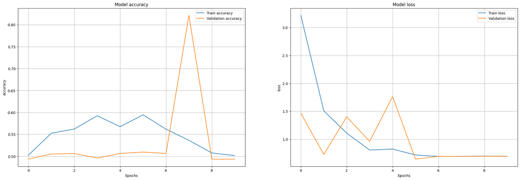

```
Test accuracy: 0.5, Test loss: 0.6932039856910706

Confusion Matrix:
```

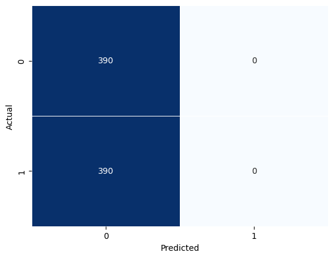

```
Classification Report:
              precision    recall  f1-score   support

      NORMAL       0.50      1.00      0.67       390
   PNEUMONIA       1.00      0.00      0.00       390

    accuracy                           0.50       780
   macro avg       0.75      0.50      0.33       780
weighted avg       0.75      0.50      0.33       780
```

```python
# history_eff_v2 = eff_v2.fit(train_data, epochs=20,validation_data = val_data)
evaluate_model(model=eff_v2, train_dataset=train_data, val_dataset=val_data, test_dataset=test_data, epochs=10)
```

For EffientNetV2B3, we got a test accuracy of 0.5 and a test loss of 0.6932. The confusion matrix shows that the model is biased towards the "NORMAL" class and cannot properly differentiate the "PNEUMONIA" class. Especially the model did not identify any of the instances of "PNEUMONIA" correctly.

## **5. VGG-16 backbone with Attention heads**

### 5.1 Self-Attention

```python
base_model = VGG16(weights='imagenet', include_top=False, input_shape=(img_height, img_width, 3))
for layer in base_model.layers:
    layer.trainable = False
```

The `SelfAttention` class is a custom implementation of a self-attention mechanism, which is a simplified version of the multi-head attention mechanism. The self-attention mechanism allows the model to weigh the importance of different features in the input by attending to different parts of the input. Here's a breakdown of the `SelfAttention` class:

1. `__init__(self, d_k)`: The constructor takes a single argument `d_k`, which is the dimension of the key, query, and value vectors in the attention mechanism. It initializes the class by calling the base class constructor and storing the `d_k` value.
2. `build(self, input_shape)`: This method is called when the layer is added to the model, and it initializes the weight matrices for the key (WK), query (WQ), and value (WV) projections. The weight matrices are of shape `(input_shape[-1], self.d_k)` and are initialized using the Glorot uniform distribution.
3. `call(self, inputs)`: This method is called during the forward pass of the model when the layer processes the input data. It takes the input tensor and does the following:

   a. Computes the query (Q), key (K), and value (V) matrices by multiplying the input tensor with the corresponding weight matrices (WQ, WK, WV).

   b. Calculates the attention logits by computing the dot product of the query (Q) and key (K) matrices, and scales the result by the square root of `d_k` to avoid gradients becoming too small or too large.

   c. Applies the softmax function to the attention logits to obtain the attention weights, which represent the importance of each feature in the input.

   d. Computes the attention output by multiplying the attention weights with the value (V) matrix. This output is a weighted sum of the input features according to their attention weights.

```python
class SelfAttention(tf.keras.layers.Layer):
    def __init__(self, d_k):
        super(SelfAttention, self).__init__()
        self.d_k = d_k

    def build(self, input_shape):
        self.WQ = self.add_weight(name='WQ', shape=(input_shape[-1], self.d_k), initializer='glorot_uniform', trainable=True)
        self.WK = self.add_weight(name='WK', shape=(input_shape[-1], self.d_k), initializer='glorot_uniform', trainable=True)
        self.WV = self.add_weight(name='WV', shape=(input_shape[-1], self.d_k), initializer='glorot_uniform', trainable=True)

    def call(self, inputs):
        Q = tf.linalg.matmul(inputs, self.WQ)
        K = tf.linalg.matmul(inputs, self.WK)
        V = tf.linalg.matmul(inputs, self.WV)
        attention_logits = tf.linalg.matmul(Q, K, transpose_b=True) / tf.sqrt(tf.cast(self.d_k, tf.float32))
        attention_weights = tf.nn.softmax(attention_logits, axis=-1)
        attention_output = tf.linalg.matmul(attention_weights, V)
        return attention_output
```

```python
global_avg_pool = layers.GlobalAveragePooling2D()(base_model.output)
attention_output = SelfAttention(d_k=64)(global_avg_pool)
predictions = layers.Dense(1, activation='sigmoid')(attention_output)
model_selfAtt = Model(inputs=base_model.input, outputs=predictions)

model_selfAtt.compile(optimizer=Adam(learning_rate=0.0001), loss='binary_crossentropy', metrics=['accuracy'])
```

```
Model Summary:
Model: "model_3"
_________________________________________________________________
 Layer (type)                Output Shape              Param #
=================================================================
 input_4 (InputLayer)        [(None, 320, 320, 3)]     0

 block1_conv1 (Conv2D)       (None, 320, 320, 64)      1792

 block1_conv2 (Conv2D)       (None, 320, 320, 64)      36928

 block1_pool (MaxPooling2D)  (None, 160, 160, 64)      0

 block2_conv1 (Conv2D)       (None, 160, 160, 128)     73856

 block2_conv2 (Conv2D)       (None, 160, 160, 128)     147584

 block2_pool (MaxPooling2D)  (None, 80, 80, 128)       0

 block3_conv1 (Conv2D)       (None, 80, 80, 256)       295168

 block3_conv2 (Conv2D)       (None, 80, 80, 256)       590080

 block3_conv3 (Conv2D)       (None, 80, 80, 256)       590080

 block3_pool (MaxPooling2D)  (None, 40, 40, 256)       0

 block4_conv1 (Conv2D)       (None, 40, 40, 512)       1180160

 block4_conv2 (Conv2D)       (None, 40, 40, 512)       2359808

 block4_conv3 (Conv2D)       (None, 40, 40, 512)       2359808

 block4_pool (MaxPooling2D)  (None, 20, 20, 512)       0

 block5_conv1 (Conv2D)       (None, 20, 20, 512)       2359808

 block5_conv2 (Conv2D)       (None, 20, 20, 512)       2359808

 block5_conv3 (Conv2D)       (None, 20, 20, 512)       2359808

 block5_pool (MaxPooling2D)  (None, 10, 10, 512)       0

 global_average_pooling2d (G  (None, 512)              0
 lobalAveragePooling2D)

 self_attention (SelfAttenti  (None, 64)               98304
 on)

 dense_6 (Dense)             (None, 1)                 65

=================================================================
Total params: 14,813,057
Trainable params: 98,369
Non-trainable params: 14,714,688
_________________________________________________________________
None
```

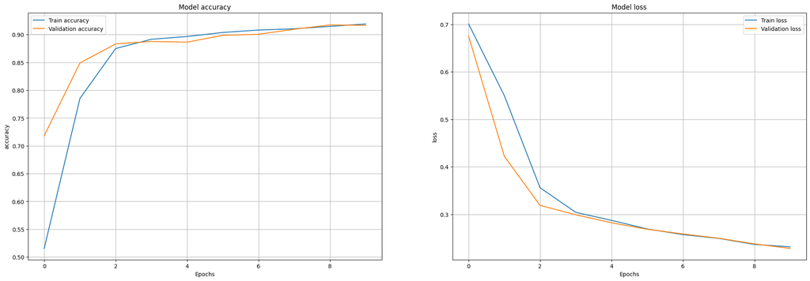

```
Test accuracy: 0.7692307829856873, Test loss: 0.5336529612541199

Confusion Matrix:
```

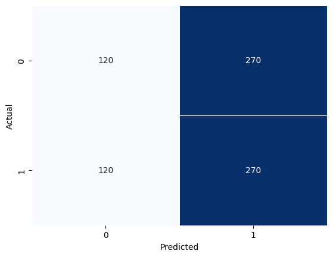

```
Classification Report:
              precision    recall  f1-score   support

      NORMAL       0.50      0.31      0.38       390
   PNEUMONIA       0.50      0.69      0.58       390

    accuracy                           0.50       780
   macro avg       0.50      0.50      0.48       780
weighted avg       0.50      0.50      0.48       780
```

```python
evaluate_model(model=model_selfAtt, train_dataset=train_data, val_dataset=val_data, test_dataset=test_data, epochs=10)
```

For VGG16 with Attention heads, we got a test accuracy of 0.7692 and a test loss of 0.5337. The confusion matrix shows that the model correctly predicted 120 instances of the "NORMAL" class and 270 instances of the "PNEUMONIA" class. However, it incorrectly predicted 270 instances of the "NORMAL" class and 120 instances of the "PNEUMONIA" class.

### 5.2 MultiHead Attention

`MultiHeadSelfAttention` is a custom Keras layer that implements the multi-head self-attention mechanism by utilizing the previously written `SelfAttention` class. It consists of the following methods:

`init(self, num_heads, d_k)`: The constructor takes two arguments, `num_heads` and `d_k`. `num_heads` specifies the number of attention heads to use, and `d_k` specifies the dimensionality of each attention head. The method initializes the class by calling the base class constructor and storing the `num_heads` and `d_k` values.

`call(self, inputs)`: This method is called during the forward pass of the model when the layer processes the input data. It takes the input tensor and does the following:

a. Applies the self-attention mechanism to the input tensor `num_heads` times using `SelfAttention` layers, each with dimensionality `d_k`.

b. Concatenates the outputs from each of the `num_heads` self-attention layers along the last axis.

c. Returns the concatenated tensor as the output of the layer.

The `MultiHeadSelfAttention` layer outputs a tensor that can be fed to the next layer in the model.

```python
class MultiHeadSelfAttention(tf.keras.layers.Layer):
    def __init__(self, num_heads, d_k):
        super(MultiHeadSelfAttention, self).__init__()
        self.num_heads = num_heads
        self.d_k = d_k
        self.attention_heads = [SelfAttention(d_k=self.d_k) for _ in range(self.num_heads)]

    def call(self, inputs):
        attention_outputs = [head(inputs) for head in self.attention_heads]
        multihead_output = tf.concat(attention_outputs, axis=-1)
        return multihead_output
```

```python
flatten_output = layers.Flatten()(base_model.output)
global_avg_pool = layers.GlobalAveragePooling1D()(flatten_output[:, None, :])
attention_output = MultiHeadSelfAttention(num_heads=2, d_k=64)(global_avg_pool)
flatten_attention_output = layers.Flatten()(attention_output)
predictions = layers.Dense(1, activation='sigmoid')(flatten_attention_output)
model_multHdAtt = Model(inputs=base_model.input, outputs=predictions)

model_multHdAtt.compile(optimizer=Adam(learning_rate=0.0001), loss='binary_crossentropy', metrics=['accuracy'])
```

```
Model Summary:
Model: "model_4"
_________________________________________________________________
 Layer (type)                Output Shape              Param #
=================================================================
 input_4 (InputLayer)        [(None, 320, 320, 3)]     0

 block1_conv1 (Conv2D)       (None, 320, 320, 64)      1792

 block1_conv2 (Conv2D)       (None, 320, 320, 64)      36928

 block1_pool (MaxPooling2D)  (None, 160, 160, 64)      0

 block2_conv1 (Conv2D)       (None, 160, 160, 128)     73856

 block2_conv2 (Conv2D)       (None, 160, 160, 128)     147584

 block2_pool (MaxPooling2D)  (None, 80, 80, 128)       0

 block3_conv1 (Conv2D)       (None, 80, 80, 256)       295168

 block3_conv2 (Conv2D)       (None, 80, 80, 256)       590080

 block3_conv3 (Conv2D)       (None, 80, 80, 256)       590080

 block3_pool (MaxPooling2D)  (None, 40, 40, 256)       0

 block4_conv1 (Conv2D)       (None, 40, 40, 512)       1180160

 block4_conv2 (Conv2D)       (None, 40, 40, 512)       2359808

 block4_conv3 (Conv2D)       (None, 40, 40, 512)       2359808

 block4_pool (MaxPooling2D)  (None, 20, 20, 512)       0

 block5_conv1 (Conv2D)       (None, 20, 20, 512)       2359808

 block5_conv2 (Conv2D)       (None, 20, 20, 512)       2359808

 block5_conv3 (Conv2D)       (None, 20, 20, 512)       2359808
```

[output cut: 9 more lines]

```
 lobalAveragePooling1D)

 multi_head_self_attention (  (None, 128)              19660800
 MultiHeadSelfAttention)

 flatten_4 (Flatten)         (None, 128)               0

 dense_7 (Dense)             (None, 1)                 129

=================================================================
Total params: 34,375,617
Trainable params: 19,660,929
Non-trainable params: 14,714,688
_________________________________________________________________
None
```

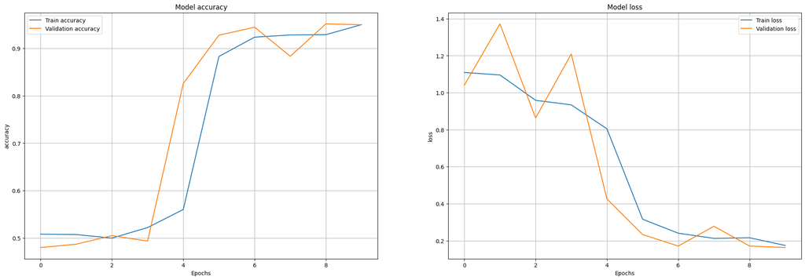

```
Test accuracy: 0.8128204941749573, Test loss: 0.6769720911979675

Confusion Matrix:
```

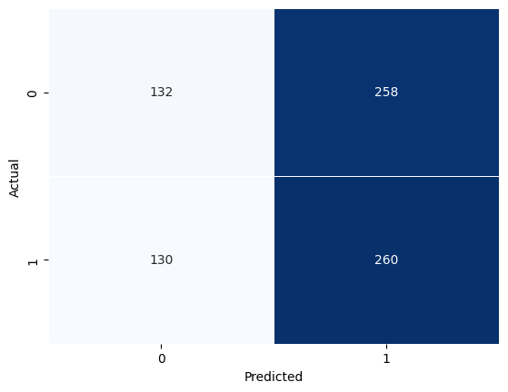

```
Classification Report:
              precision    recall  f1-score   support

      NORMAL       0.50      0.34      0.40       390
   PNEUMONIA       0.50      0.67      0.57       390

    accuracy                           0.50       780
   macro avg       0.50      0.50      0.49       780
weighted avg       0.50      0.50      0.49       780
```

```python
evaluate_model(model=model_multHdAtt, train_dataset=train_data, val_dataset=val_data, test_dataset=test_data, epochs=10)
```

For VGG16 with MultiHead Attention, we achieved a test accuracy of 0.8128 and a test loss of 0.6770. In addition, the confusion matrix shows that the model correctly predicted 260 instances of the "PNEUMONIA" class, which requires more attention due to its potential severity. However, the model incorrectly predicted 258 instances of the "NORMAL" class, indicating that there is still room for improvement in terms of specificity for this class.

## **6. Visual Transformers (ViT)**

The code snippet defines a function `create_vit_classifier()` that creates a classification model using the Vision Transformer (ViT) architecture. The function returns a Keras model that takes an input tensor of shape `(img_height, img_width, 3)` and outputs a single scalar value between 0 and 1.

The ViT model is created using the `vit_b32()` function from the vit module, which is a pre-trained ViT model with 32 attention layers. The function takes several arguments including the input image size, activation function, pre-trained weights, and number of classes.

The function then defines an input layer and applies a rescaling layer to normalize the input pixel values between 0 and 1. The output of the ViT model is then computed by passing the rescaled input tensor to the model.

```python
def create_vit_classifier():
    model = vit.vit_b32(
        image_size=img_height,
        activation='sigmoid',
        pretrained=True,
        include_top=True,
        pretrained_top=False,
        classes=1,
        weights='imagenet21k'
    )

    input_layer = tf.keras.layers.Input(shape=(img_height, img_width, 3))
    x = tf.keras.layers.experimental.preprocessing.Rescaling(1./255)(input_layer)
    output = model(x)

    return tf.keras.Model(inputs=input_layer, outputs=output)

model_vit = create_vit_classifier()
model_vit.compile(optimizer=tf.keras.optimizers.Adam(learning_rate=0.001),
                       loss=tf.keras.losses.BinaryCrossentropy(),
                       metrics=['accuracy'])
```

```
Model Summary:
Model: "model_5"
_________________________________________________________________
 Layer (type)                Output Shape              Param #
=================================================================
 input_6 (InputLayer)        [(None, 320, 320, 3)]     0

 rescaling_1 (Rescaling)     (None, 320, 320, 3)       0

 vit-b32 (Functional)        (None, 1)                 88085761

=================================================================
Total params: 88,085,761
Trainable params: 88,085,761
Non-trainable params: 0
_________________________________________________________________
None
```

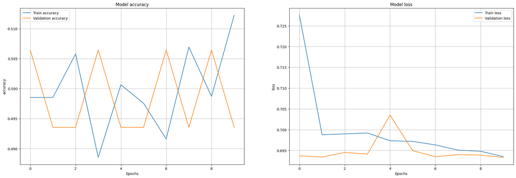

```
Test accuracy: 0.5, Test loss: 0.6931963562965393

Confusion Matrix:
```

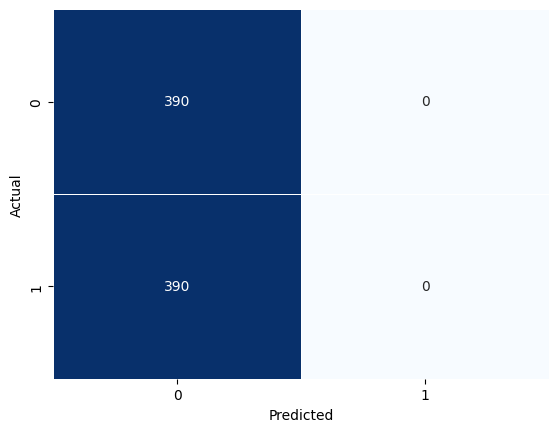

```
Classification Report:
              precision    recall  f1-score   support

      NORMAL       0.50      1.00      0.67       390
   PNEUMONIA       1.00      0.00      0.00       390

    accuracy                           0.50       780
   macro avg       0.75      0.50      0.33       780
weighted avg       0.75      0.50      0.33       780
```

```python
evaluate_model(model=model_vit, train_dataset=train_data, val_dataset=val_data, test_dataset=test_data, epochs=10)
```

For Visual Transformers, we got a test accuracy of 0.5 and a test loss of 0.6932. The confusion matrix shows that the model predicted all instances as "NORMAL" and none as "PNEUMONIA." From the classification, the precision is equal to 1, and the recall for "PNEUMONIA" is 0, which means the model cannot correctly identify any "PNEUMONIA" cases.

## **7. Results**

Precision and Recall of Pneumonia class were used.

| SNo. | Training | Parameters | Test Accuracy | Precision | Recall | F1 Score | Comments |
| --- | --- | --- | --- | --- | --- | --- | --- |
| 1 | VGG-16 + Dense head | 27,822,401 | 0.6872 | 0.5 | **0.82** | **0.62** | Highest Recall, F1 |
| 2 | Inception-V3 + Dense head | 55,357,729 | 0.7218 | 0.51 | 0.78 | 0.62 |  |
| 3 | EfficientNetV2B3 + Dense head | 52,252,735 | 0.5000 | 1.00 | 0.00 | 0.00 |  |
| 4 | VGG-16 + SelfAttention Head | 14,813,057 | 0.7692 | 0.50 | 0.69 | 0.58 | Smallest model |
| 5 | VGG-16 + MultiHead Attention | 34,375,617 | **0.8128** | 0.50 | 0.67 | 0.57 | Highest Test Accuracy |
| 6 | ViT | 88,085,761 | 0.5000 | 1.00 | 0.00 | 0.00 |  |

In the above experiment, it can be observed that the VGG-16 + Dense head for the given set of training parameters was most effective with the highest recall and f1 score. On the other hand, Multi-Head Attention on top of VGG-16 network provided better accuracies overall.

## **8. Conclusions**

In this project, we explored different backbone architectures along with dense heads, attention heads, and visual transformers for the task of binary classification of chest X-ray images to detect COVID-19. Our goal was to find a model that could achieve a high recall value for the "PNEUMONIA" class, as the consequences of a false negative can be severe in the context of COVID-19 diagnosis.

From our experiments, we observed that the VGG-16 with a Dense head provided the highest recall and F1 score, making it the most effective model for our purpose. Furthermore, the VGG-16 with Multi-Head Attention achieved the highest test accuracy among all the models. On the other hand, models based on EfficientNetV2B3 and ViT did not perform well on this specific task.

## **9. Learning Outcomes**

1. Gained experience in implementing custom models in Keras with custom architectures such as self-attention and multi-head attention mechanisms.
2. Explored various backbone architectures, including VGG-16, InceptionV3, EfficientNetV2B3, and Visual Transformers (ViT), for the medical image classification task.
3. Understood the importance of recall in the context of COVID-19 diagnosis from chest X-ray images and the potential consequences associated with false negatives.
4. Learned how to handle class imbalance in the dataset using oversampling techniques.
5. Developed skills in evaluating model performance using metrics such as accuracy, precision, recall, F1 score, confusion matrix, and classification reports.
6. Gained insights on the trade-offs between different models in terms of performance, model complexity, and size.
7. Understood the potential areas for improvement and future work, such as exploring other backbone architectures, ensemble methods, data augmentation, and fine-tuning of model parameters.

## **10. References**

1. Mooney, P. T. (n.d.). Chest X-Ray Images (Pneumonia). Kaggle. Retrieved from https://www.kaggle.com/datasets/paultimothymooney/chest-xray-pneumonia
2. Lemaitre, G., Nogueira, F., & Aridas, C. K. (n.d.). imblearn.over_sampling.RandomOverSampler. imbalanced-learn. Retrieved from https://imbalanced-learn.org/stable/references/generated/imblearn.over_sampling.RandomOverSampler.html
3. Weights & Biases Authors. (n.d.). Simple Ways to Tackle Class Imbalance. Weights & Biases. Retrieved from https://wandb.ai/authors/class-imbalance/reports/Simple-Ways-to-Tackle-Class-Imbalance--VmlldzoxODA3NTk
4. Stack Overflow Contributors. (2017, November 14). Oversampling functionality in TensorFlow Dataset API. Stack Overflow. Retrieved from https://stackoverflow.com/questions/47236465/oversampling-functionality-in-tensorflow-dataset-api
5. Mooney, P. T. (n.d.). Exploring the Kaggle API. Kaggle. Retrieved from https://www.kaggle.com/code/paultimothymooney/exploring-the-kaggle-api
6. Morales, F. (n.d.). vit-keras: Implementation of Vision Transformers in Keras. GitHub. Retrieved from https://github.com/faustomorales/vit-keras
7. Morales, F., & Contributors (n.d.). Issue #35: How to use ViT for regression? GitHub. Retrieved from https://github.com/faustomorales/vit-keras/issues/35
8. Papers with Code Contributors (n.d.). Vision Transformer Method Page on Papers with Code. Papers with Code. Retrieved from https://paperswithcode.com/method/vision-transformer
9. TensorFlow Contributors (n.d.). tf.keras.layers.MultiHeadAttention API documentation page on TensorFlow.org. TensorFlow.org. Retrieved from https://www.tensorflow.org/api_docs/python/tf/keras/layers/MultiHeadAttention
10. TensorFlow Contributors (n.d.). Neural machine translation with attention tutorial on TensorFlow.org Text Tutorials section.TensorFlow.org.Retrieved from https://www.tensorflow.org/text/tutorials/nmt_with_attention
11. Vaswani, A., Shazeer, N., Parmar, N., Uszkoreit, J., Jones, L., Gomez, A.N., Kaiser,L., & Polosukhin,I.(2017). Attention Is All You Need.arXiv preprint arXiv:1706.03762.Retrieved from https://arxiv.org/pdf/1706.03762.pdf
12. ChatGPT. (2023, April 1 - 2023, April 6). [Mostly debugging questions from code implementation of concepts] [Response to the user questions]. Retrieved from https://chat.openai.com/chat